# Tidyverse: datos de desarrollo humano

[Tidyverse](https://www.tidyverse.org/) es un conjunto de librerías o paquetes - realmente se debería usar la palabra biblioteca pero no se suele hacer - que comparten, además de un mismo enfoque al programar, una serie de funcionalidades muy útiles al analizar datos.

Este estilo de programación se aproxima a la programación funcional y se basa en las llamadas encadenadas a funciones o *verbos*. Estas llamadas reiteradas se hacen con el operador *pipe* que se escribe usando el símbolo **%>%**.

Vamos a centrarnos, en primer lugar, en el [paquete dplyr](https://dplyr.tidyverse.org/) manipular datos, de ahí su nombre. Entre en el enlace y fíjese en las funciones o verbos de dicho paquete: *filter*, *select*, *mutate*, etc. Localice la hoja resumen de dicho paquete - *Cheatsheet* - y échele un vistazo antes de hacer los ejercios.

# Ejercicio 1: verbos de *dplyr*

### Previo

Antes de comenzar, si no se ha creado un proyecto nuevo, ¿está seguro del directorio de trabajo en el que está trabajando y si hay objetos cargados previamente en memoria?

```r
# Comprobacion del directorio de trabajo
getwd()
```

```
[1] "C:/Users/david/OneDrive - UNIVERSIDAD DE SEVILLA/Máster Cloud, Datos y Gestión TI/FID/Lecciones/Lección 1/Análisis exploratorio de datos con Tidyverse"
```

```r
#setwd(".. ruta de la carpeta deseada ..")
#getwd()

# Comprobacion de que no hay objetos previamente cargados
ls() # inidca objetos cargados
```

```
character(0)
```

```r
#rm(list = ls()) # borra todos los objetos cargados
#ls()
```

Cargue la librería antes de comenzar a trabajar. Si no ha instalado previamente el paquete *dplyr* deberá hacerlo. Si ya instalado en el ordenador de trabajo *Tidyverse* entonces no le hará falta. (Observe la consola al realizar la instalación y siga las instrucciones si hicera falta).

```r
# Instalación del paquete (sólo si no se ha hecho antes)
install.packages("dplyr")
# Cargar la librería
#library(dplyr)
```

En este ejercicio vamos a trabajar con datos de desarrollo humano que vienen dados en el paquete gapminder. Consulte el enlace de wikipedia [Gapminder Foundation](https://en.wikipedia.org/wiki/Gapminder_Foundation) para saber de dónde provienen estos datos.

```r
install.packages('gapminder')
```

### Un vistazo a los datos

Use las funcions *head* y *str*, de *R-base*, para ver cómo son los datos que vamos a utilizar.

Las variables que contiene son país, continente donde está situado el país, año de los datos registrados, esperanza de vida (lifeExp), población total del país (pop) y producto interior bruto por persona en dólares (gdpPercap).

| country | continent | year | lifeExp | pop | gdpPercap |
| --- | --- | --- | --- | --- | --- |
| Afghanistan | Asia | 1952 | 28.801 | 8425333 | 779.4453 |
| Afghanistan | Asia | 1957 | 30.332 | 9240934 | 820.8530 |
| Afghanistan | Asia | 1962 | 31.997 | 10267083 | 853.1007 |
| Afghanistan | Asia | 1967 | 34.020 | 11537966 | 836.1971 |
| Afghanistan | Asia | 1972 | 36.088 | 13079460 | 739.9811 |
| Afghanistan | Asia | 1977 | 38.438 | 14880372 | 786.1134 |

### Operaciones con el operador pipe: dplyr

**Filtremos** aquellas observaciones del año 2007.

| country | continent | year | lifeExp | pop | gdpPercap |
| --- | --- | --- | --- | --- | --- |
| Afghanistan | Asia | 2007 | 43.828 | 31889923 | 974.5803 |
| Albania | Europe | 2007 | 76.423 | 3600523 | 5937.0295 |
| Algeria | Africa | 2007 | 72.301 | 33333216 | 6223.3675 |
| Angola | Africa | 2007 | 42.731 | 12420476 | 4797.2313 |
| Argentina | Americas | 2007 | 75.320 | 40301927 | 12779.3796 |
| Australia | Oceania | 2007 | 81.235 | 20434176 | 34435.3674 |
| Austria | Europe | 2007 | 79.829 | 8199783 | 36126.4927 |
| Bahrain | Asia | 2007 | 75.635 | 708573 | 29796.0483 |
| Bangladesh | Asia | 2007 | 64.062 | 150448339 | 1391.2538 |
| Belgium | Europe | 2007 | 79.441 | 10392226 | 33692.6051 |

[output cut: 132 more lines]

Tenga en cuenta que la operación anterior es una operación virtual, en el sentido que el contenido del objeto *gapminder* no se modifica. Si quiere almacenar el resultado deberá asignarlo en una variable auxiliar.

Así mismo, observe el estilo de escritura de esta forma de programar. Por ejemplo, aunque sea una sola sentencia de código se suele poner un verbo en cada línea, cómo funciona el autocompletar si está utiizando R-Studio, etc.

**Filtremos** aquellas observaciones de Estados Unidos para el año 2007.

| country | continent | year | lifeExp | pop | gdpPercap |
| --- | --- | --- | --- | --- | --- |
| United States | Americas | 2007 | 78.242 | 301139947 | 42951.65 |

El verbo **arrange** se utiliza para realizar reordenaciones en el dataset.

**Ordenemos** según el PIB per cápita - GDP en inglés - de forma ascendente y descendente.

| country | continent | year | lifeExp | pop | gdpPercap |
| --- | --- | --- | --- | --- | --- |
| Kuwait | Asia | 1957 | 58.033 | 212846 | 113523.133 |
| Kuwait | Asia | 1972 | 67.712 | 841934 | 109347.867 |
| Kuwait | Asia | 1952 | 55.565 | 160000 | 108382.353 |
| Kuwait | Asia | 1962 | 60.470 | 358266 | 95458.112 |
| Kuwait | Asia | 1967 | 64.624 | 575003 | 80894.883 |
| Kuwait | Asia | 1977 | 69.343 | 1140357 | 59265.477 |
| Norway | Europe | 2007 | 80.196 | 4627926 | 49357.190 |
| Kuwait | Asia | 2007 | 77.588 | 2505559 | 47306.990 |
| Singapore | Asia | 2007 | 79.972 | 4553009 | 47143.180 |
| Norway | Europe | 2002 | 79.050 | 4535591 | 44683.975 |

[output cut: 990 more lines]

El verbo **mutate** permite modificar el dataset añadiendo nuevas variables o realizando cambios en las existentes.

**Modifiquemos** la variable población de manera que los valores sean por millón de habitantes. Es decir, dividamos la población actual entre 1000000.

| country | continent | year | lifeExp | pop | gdpPercap |
| --- | --- | --- | --- | --- | --- |
| Afghanistan | Asia | 1952 | 28.80100 | 8.425333 | 779.4453 |
| Afghanistan | Asia | 1957 | 30.33200 | 9.240934 | 820.8530 |
| Afghanistan | Asia | 1962 | 31.99700 | 10.267083 | 853.1007 |
| Afghanistan | Asia | 1967 | 34.02000 | 11.537966 | 836.1971 |
| Afghanistan | Asia | 1972 | 36.08800 | 13.079460 | 739.9811 |
| Afghanistan | Asia | 1977 | 38.43800 | 14.880372 | 786.1134 |
| Afghanistan | Asia | 1982 | 39.85400 | 12.881816 | 978.0114 |
| Afghanistan | Asia | 1987 | 40.82200 | 13.867957 | 852.3959 |
| Afghanistan | Asia | 1992 | 41.67400 | 16.317921 | 649.3414 |
| Afghanistan | Asia | 1997 | 41.76300 | 22.227415 | 635.3414 |

[output cut: 990 more lines]

**Añadimos** una nueva variable que sea el PIB per cápita por la población.

| country | continent | year | lifeExp | pop | gdpPercap | gdp |
| --- | --- | --- | --- | --- | --- | --- |
| Afghanistan | Asia | 1952 | 28.80100 | 8425333 | 779.4453 | 6.567086e+09 |
| Afghanistan | Asia | 1957 | 30.33200 | 9240934 | 820.8530 | 7.585449e+09 |
| Afghanistan | Asia | 1962 | 31.99700 | 10267083 | 853.1007 | 8.758856e+09 |
| Afghanistan | Asia | 1967 | 34.02000 | 11537966 | 836.1971 | 9.648014e+09 |
| Afghanistan | Asia | 1972 | 36.08800 | 13079460 | 739.9811 | 9.678553e+09 |
| Afghanistan | Asia | 1977 | 38.43800 | 14880372 | 786.1134 | 1.169766e+10 |
| Afghanistan | Asia | 1982 | 39.85400 | 12881816 | 978.0114 | 1.259856e+10 |
| Afghanistan | Asia | 1987 | 40.82200 | 13867957 | 852.3959 | 1.182099e+10 |
| Afghanistan | Asia | 1992 | 41.67400 | 16317921 | 649.3414 | 1.059590e+10 |
| Afghanistan | Asia | 1997 | 41.76300 | 22227415 | 635.3414 | 1.412200e+10 |

[output cut: 990 more lines]

El verbo **sumarise** permite realizar operaciones. Este verbo permite realizar operaciones con los valores de las columnas del dataset.

**Calcule** la media de la esperanza de vida de todo el dataset.

| media |
| --- |
| 59.47444 |

| sum |
| --- |
| 101344.4 |

En general se suelen combinar varios verbos a la vez. Por ejemplo, calcule la esperanza de vida para aquellas observaciones que sean del año 2007.

| media |
| --- |
| 67.00742 |

El verbo **group_by** separar o clasificar los datos según una característica en concreto. Se asocian las observaciones a una carácterística común.

Obtenga la media de la esperanza de vida según en primer lugar según el año.

| year | media |
| --- | --- |
| 1952 | 49.05762 |
| 1957 | 51.50740 |
| 1962 | 53.60925 |
| 1967 | 55.67829 |
| 1972 | 57.64739 |
| 1977 | 59.57016 |
| 1982 | 61.53320 |
| 1987 | 63.21261 |
| 1992 | 64.16034 |
| 1997 | 65.01468 |

[output cut: 2 more lines]

Obtenga la media de la esperanza de vida según en segundo lugar según el continente.

| continent | media |
| --- | --- |
| Africa | 48.86533 |
| Americas | 64.65874 |
| Asia | 60.06490 |
| Europe | 71.90369 |
| Oceania | 74.32621 |

# Ejercicio 2: verbos de **ggplot2**

El [paquete ggplot2][https://ggplot2.tidyverse.org/] está integrado en Tidyverse y permite realizar gráficas usando el operador **pipe**. Entre en su enlace y échele un vistazo a su hoja explicativa (Cheatsheet).

### Previo

Instale el paquete ggplot2 si no lo tenía instalado previamente, recuerde que si hizo la instalación de Tidyverse al completo ya está instalado, y cargue dicha librería.

Cree una variable de nombre **gapminder_2007** con los datos filtrados para el año 2007.

| country | continent | year | lifeExp | pop | gdpPercap |
| --- | --- | --- | --- | --- | --- |
| Afghanistan | Asia | 2007 | 43.828 | 31889923 | 974.5803 |
| Albania | Europe | 2007 | 76.423 | 3600523 | 5937.0295 |
| Algeria | Africa | 2007 | 72.301 | 33333216 | 6223.3675 |
| Angola | Africa | 2007 | 42.731 | 12420476 | 4797.2313 |
| Argentina | Americas | 2007 | 75.320 | 40301927 | 12779.3796 |
| Australia | Oceania | 2007 | 81.235 | 20434176 | 34435.3674 |
| Austria | Europe | 2007 | 79.829 | 8199783 | 36126.4927 |
| Bahrain | Asia | 2007 | 75.635 | 708573 | 29796.0483 |
| Bangladesh | Asia | 2007 | 64.062 | 150448339 | 1391.2538 |
| Belgium | Europe | 2007 | 79.441 | 10392226 | 33692.6051 |

[output cut: 132 more lines]

### Representación de dos variables.

Vamos a estudiar la varible PIB per cápita (gdpPercap) frente a la esperanza de vida (lifeExp).

Observe la siguiente llamada.

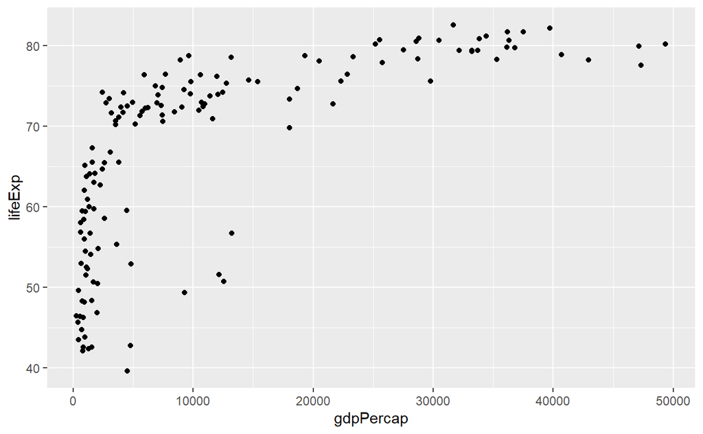

Modifique la grafica de modo que en el eje x aparezca gdpPercap y en el lifeExp. No copie y pegue el código sino escríbalo poco a poco, dejese ayudar por el autocompletar de R-Studio.

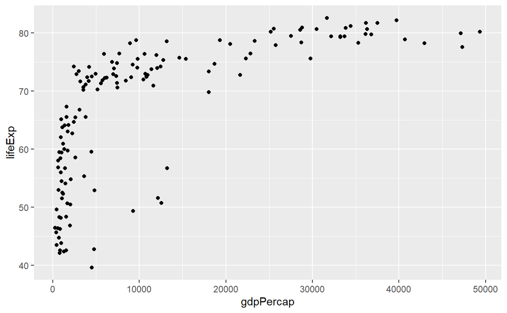

Añadamos una transformación logarítimica a la gráfica anterior. Escriba scale_ y lea las opciones que le ofrece el autocompletar.

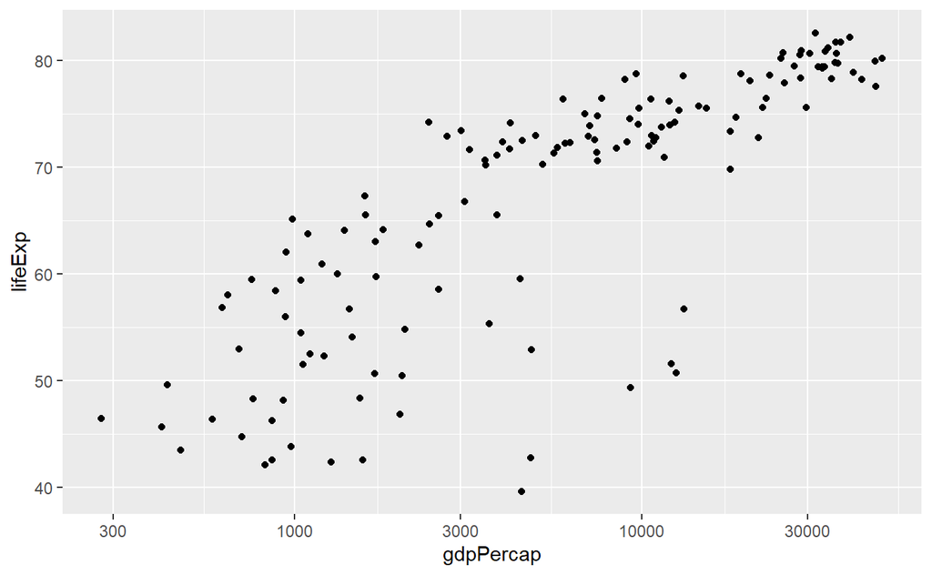

Añadamos un color según el continente a la gráfica anterior. Escriba un parámetro adicional en aes que se llame color y asignale la variable “continent”.

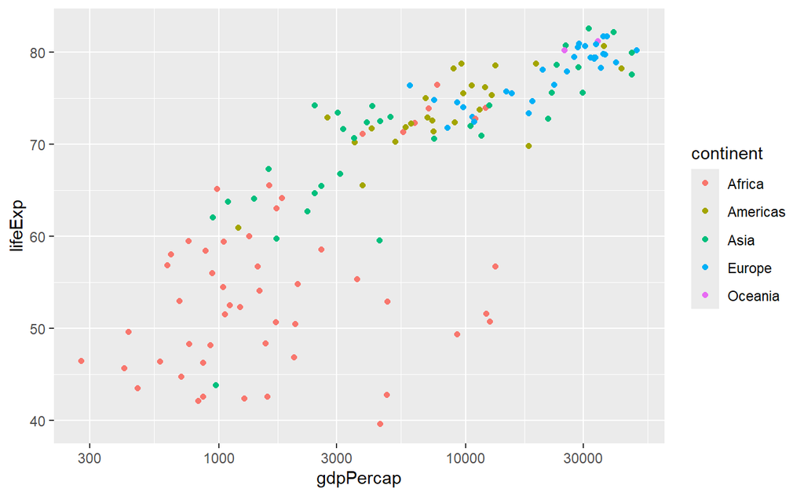

Añada el tamaño de la población a la gráfica anterior, de manera que cada punto esté relacionado con el tamaño de la población. Añada un valor adicional a aes - además de x, y, color - de nombre size y asígnele la variable pop.

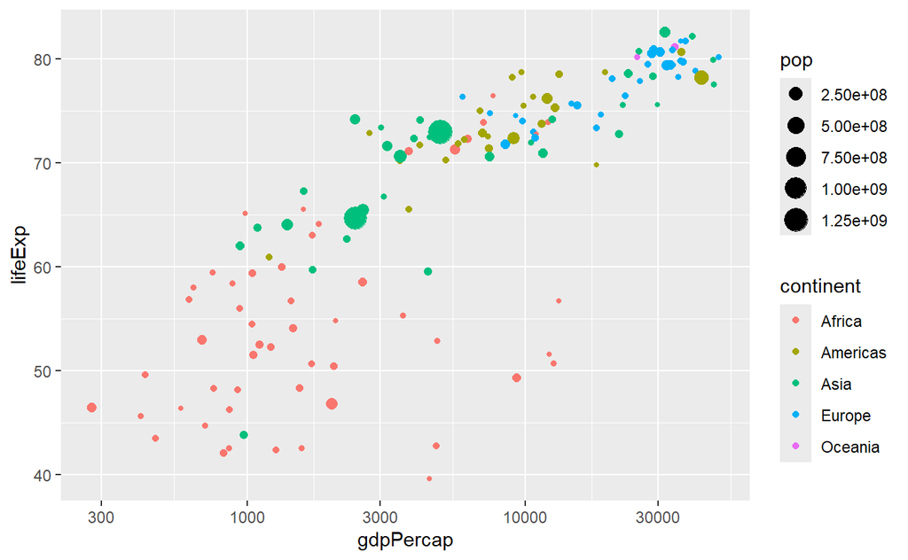

Repitamos la gráfica anterior pero estudiando cada continente de manera separada. Para ello añada al final “+_facet_wrap(~variable)” siendo la variable el continente. (Use el autocompletar de código).

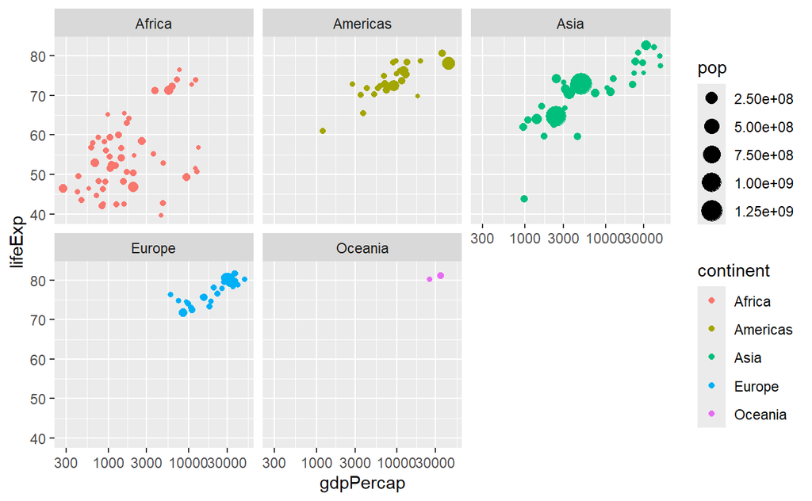

### Representación de dos variables: continuación

Al igual que las gráficas anteriores vamos a estudiar el PIB per cápita según la esperanza de vida. Veamos las distintas opciones que podemos elegir. Filtraremos siempre según el año 2007. (Puede usar la variable anterior o combinar el filtrado con el dibujo).

Repitamos la gráfica del principio estudiando las opcions: geom_point, geom_line, geom_area, geom_smooth. (Escriba código utilizando en autocompletar)

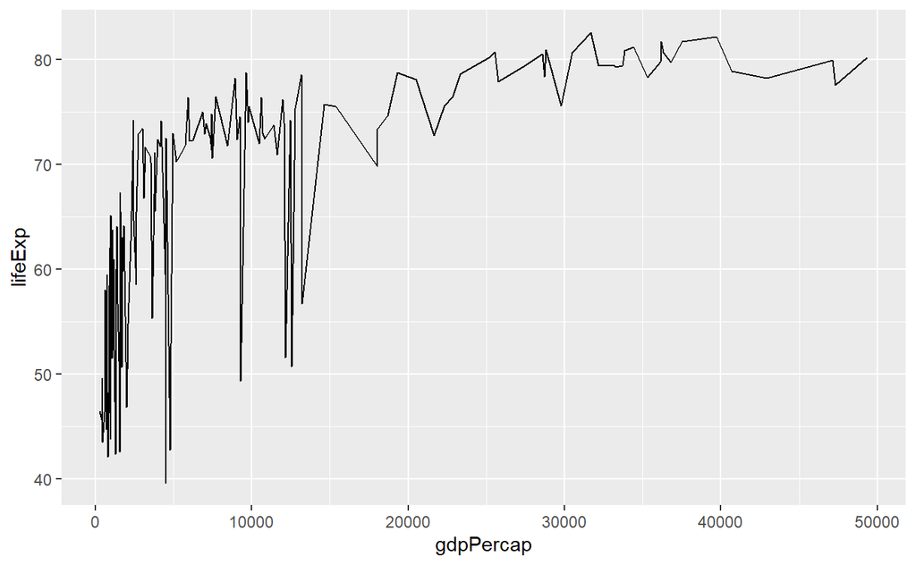

Constramos un diagrama de barras de manera que tenga en el eje x los continentes y en el y la esperanza de vida. Utilice la opción geom_col() después de la función ggplot. (Use el autocompletar de código).

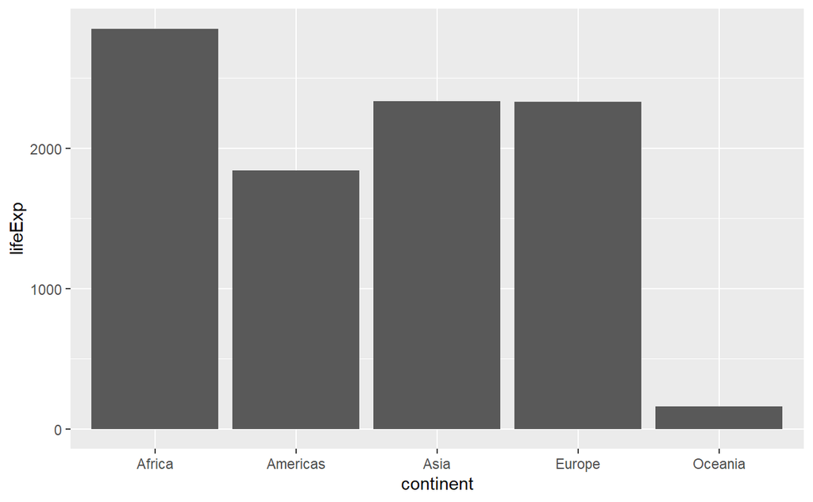

Realicemos ahora el histograma de los valores de la esperanza de vida. Basta usar la opción geom_histogram() después de ggplot y, en aes, la x asignada a lifeExp.

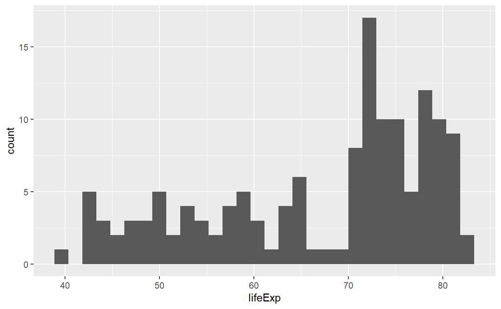

Repetimos la gráfica anterior ajustando según el ancho. (Basta poner “binwidth = 5”) dentro de geom_histogram().

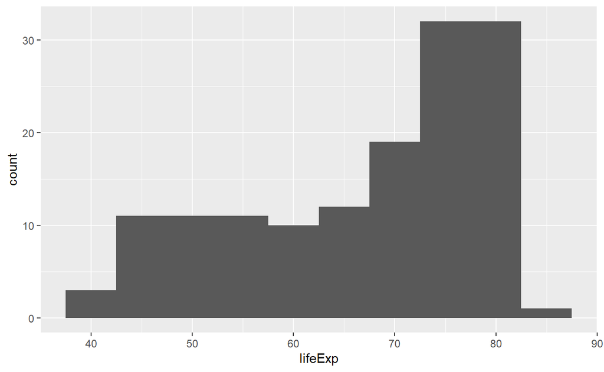

Construyamos el *boxplot*, o diagrama de cajas, de la esperanza de vida. ¿Cómo interpeta la gráfica resultante? Basta añadir la opción geom_boxplot() después de ggplot, en aes ponga x con valor 1 y la y con lifeExp. (Utilice el autcompletar)

[Boxplot](https://es.wikipedia.org/wiki/Diagrama_de_caja)

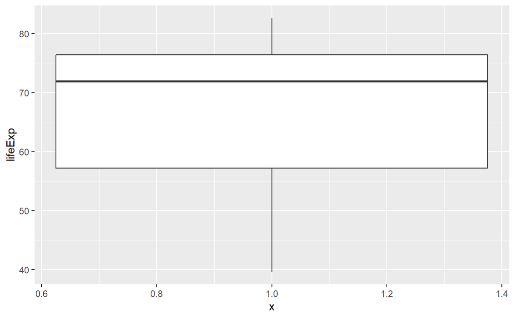

Repita la gráfica anterior pero separando según el continente. Basta poner en el valor de x la variable continent.

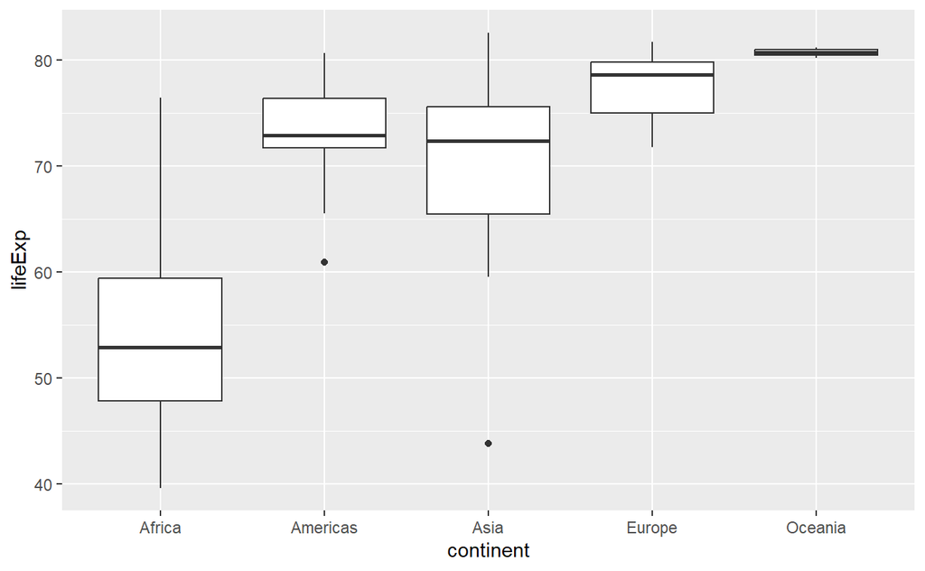

### Representación mediante in gráfico interactivo

Veamos la evolución de la esperanza de vida a través de un gráfico interactivo. Se empleará la librería *plotly*.

[interactive chart not shown]